Repeat the histogram with the imputed data frame . Check if there is a difference in the estimates and what is the impact of imputing missing values ?

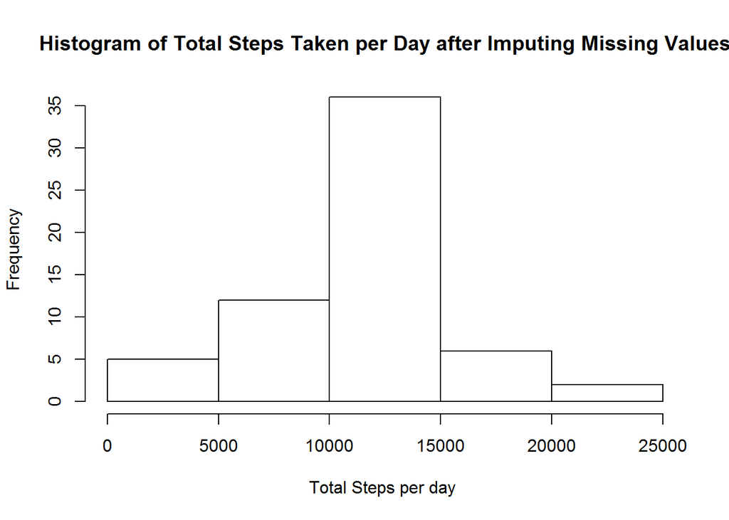

```r
imputed_totalStepsDay <- tapply(ReplacedDF$steps , ReplacedDF$Date1 , sum)

hist(imputed_totalStepsDay , xlab = "Total Steps per day " , main = "Histogram of Total Steps Taken per Day after Imputing Missing Values")
```

Compute the new mean amd median of total steps taken per day.

```r
summary(imputed_totalStepsDay)
```

```
##    Min. 1st Qu.  Median    Mean 3rd Qu.    Max.
##      41    9819   10770   10770   12810   21190
```

The mean changes from 9354 to 10770 .

Check for change in the activty pattern between weekdays and weekend:

Find out the day of the week . Set a factor variable to ‘0’for weekday and ’1’ for weekend.

```r
ReplacedDF <- mutate(ReplacedDF, Day =  weekdays(Date1))
SetDay <- function(x){

  weekend = c("Saturday","Sunday")

  if (x %in% weekend ) {
    y <- '1' }
  else
    y <- '0'
  return(y)  }
ReplacedDF$DayFactor <- sapply(ReplacedDF$Day , SetDay)
ReplacedDF$DayFactor <- factor(ReplacedDF$DayFactor , labels = c("Weekday" , "Weekend"))
```

Create a panel plot of average steps per interval across all dates for weekday and weekend respectively.

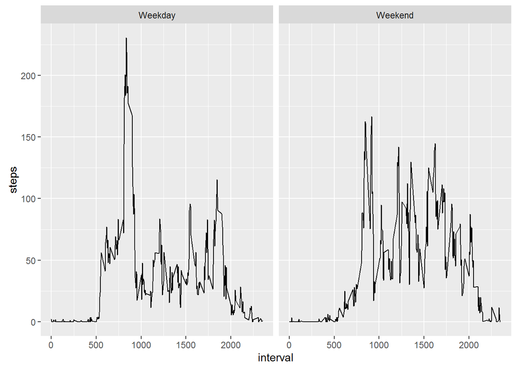

```r
MeanStep_DayInterval_2 <- aggregate(steps ~ DayFactor + interval , data = ReplacedDF , FUN = "mean")

library(ggplot2)
g <- ggplot(MeanStep_DayInterval_2 , aes(interval ,steps ))

g+ geom_line() + facet_grid(.~ DayFactor)
```